# Fundamentos de Pesquisa em Ciência da Computação 2

Lab 3 - Checkpoint 1

16 de maio de 2018

## **Inferência Estatística aplicada às Sessões, Buscas e Navegação na Wikimedia**

Neste relatório, apresentam-se conclusões baseadas em inferência estatística sobre o *dataset* search_data.scv (extraído de https://meta.wikimedia.org/wiki/Schema:TestSearchSatisfaction2).

O relatório está organizado de acordo com as seguintes seções: As 2 seções iniciais descrevem as bibliotecas utilizadas e os procedimentos para a importação do dataset. Na seção 3, exibem-se as respostas, baseadas em inferência estatística, para os 3 questionamentos, a seguir:

- 1. Qual é taxa diária de cliques? Como isso varia entre os grupos (A e B)? Nesta subseção, consideram-se 2 análises: (i) teste A/B, no qual se investa a variação entre os grupos A e B e (ii) teste A/A que compara a metade das sessões de busca do grupo A com a outra metade das sessões do mesmo grupo.
- 2. Quais resultados de busca, as pessoas tendem a tentar primeiro? Como isso muda ao longo do dia-a-dia?
- 3. Qual é taxa diária de zero resultados? Como isso varia entre os grupos (A e B)?

A seção 4 apresenta a conclusão geral sobre a população, concebida a partir de inferência estatística.

Ressalta-se que a inferência estatística é baseada no nível de confiança de 95% e *bootstrap* (2000 repetições para amostras de tamanho 40).

### **1. Bibliotecas Utilizadas**

```r
library(tidyverse)
library(here)
library(lubridate)
library(summarytools)
library(boot)  ##para bootstrap
theme_set(theme_bw())
```

### **2. Importação dos Dados**

```r
buscas_original = read_csv(here::here("data/search_data.csv"))
glimpse(buscas_original) ##visualizando as observações pré-filtragens
```

```
## Observations: 136,234
## Variables: 8
## $ session_id              <chr> "0000cbcb67c19c45", "0001382e027b2ea4"...
## $ search_index            <int> 1, 1, 1, 1, 2, 3, 4, 5, 6, 1, 1, 2, 1,...
## $ session_start_timestamp <dbl> 2.016030e+13, 2.016031e+13, 2.016031e+...
## $ session_start_date      <dttm> 2016-03-03 15:20:45, 2016-03-07 08:49...
## $ group                   <chr> "b", "b", "b", "a", "a", "a", "a", "a"...
## $ results                 <int> 20, 18, 20, 20, 20, 20, 20, 20, 20, 1,...
## $ num_clicks              <int> 0, 1, 1, 0, 0, 0, 0, 0, 0, 0, 0, 1, 0,...
## $ first_click             <int> NA, 1, 1, NA, NA, NA, NA, NA, NA, NA, ...
```

A partir da tabela, nota-se que há 136.234 observações.

### **3. Respostas aos Questionamentos**

#### **3.1 Qual é taxa diária de *clickthrough*? Como isso varia entre os grupos?**

##### **Qual é taxa diária de *clickthrough*?**

```r
buscas = buscas_original %>%
  filter(results > 0)
glimpse(buscas) ##visualizando as observações pós-filtragem
```

```
## Observations: 111,107
## Variables: 8
## $ session_id              <chr> "0000cbcb67c19c45", "0001382e027b2ea4"...
## $ search_index            <int> 1, 1, 1, 1, 2, 3, 4, 5, 6, 1, 2, 1, 1,...
## $ session_start_timestamp <dbl> 2.016030e+13, 2.016031e+13, 2.016031e+...
## $ session_start_date      <dttm> 2016-03-03 15:20:45, 2016-03-07 08:49...
## $ group                   <chr> "b", "b", "b", "a", "a", "a", "a", "a"...
## $ results                 <int> 20, 18, 20, 20, 20, 20, 20, 20, 20, 1,...
## $ num_clicks              <int> 0, 1, 1, 0, 0, 0, 0, 0, 0, 0, 1, 0, 3,...
## $ first_click             <int> NA, 1, 1, NA, NA, NA, NA, NA, NA, NA, ...
```

O *dataframe* sessions_by_date armazena as taxas diárias de *clickthough*.

```r
sessions_by_date = buscas %>%
  group_by(date(session_start_date)) %>%       ##agrupando por data da ocorrência da sessão
  summarize(total_sessions_by_date = n(),
            total_sessions_with_clicks_by_date = sum(num_clicks > 0),
            rate = (total_sessions_with_clicks_by_date/total_sessions_by_date) * 100)

glimpse(sessions_by_date)
```

```
## Observations: 8
## Variables: 4
## $ `date(session_start_date)`         <date> 2016-03-01, 2016-03-02, 20...
## $ total_sessions_by_date             <int> 14927, 15313, 15716, 13660,...
## $ total_sessions_with_clicks_by_date <int> 4362, 4476, 4703, 4189, 325...
## $ rate                               <dbl> 29.22221, 29.23007, 29.9249...
```

A figura 1 exibe a distribuição de taxas de *clickthrough* por data de ocorrência.

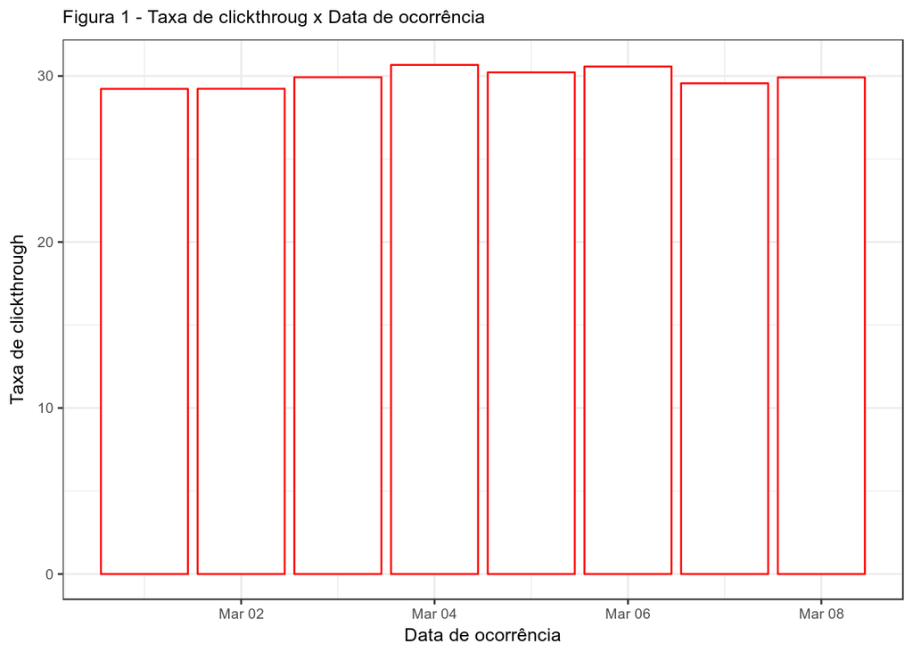

```r
sessions_by_date %>%
    ggplot(aes(y = rate, x = `date(session_start_date)`)) +
    ggtitle("Figura 1 - Taxa de clickthroug x Data de ocorrência") +
    geom_bar(stat = "identity", fill = "white", color = "red") +
    ylab("Taxa de clickthrough") +
    xlab("Data de ocorrência") +
    theme(text = element_text(family = "Arial", size = 10), plot.title = element_text(size = 10), axis.title.x = element_text(size = 10), axis.title.y = element_text(size = 10))
```

Calcula-se a média das taxas diárias de *clickthrough*.

```r
print(mean(sessions_by_date$rate))
```

```
## [1] 29.91347
```

Portanto, aproximadamente, em 29,9% das sessões diárias, os usuários clicam em algum resultado de busca. Nesse contexto, a média das taxas diárias de *clickthrough* será considerada para fins de inferência estatística.

A partir do *dataframe* buscas, é extraída uma amostra e o processo de *bootstraping* é iniciado. A figura 2 exibe a distribuição amostral das médias de taxas diárias de *clickthrough* calculadas. Em seguida, calcula-se o intervalo de confiança.

```r
set.seed(123)    ## semente 'aleatória' para a aleatoriedade de amostras

experimento = sample_n(buscas, 40)   ## obtém amostra de tamanho 40
glimpse(experimento)
```

```
## Observations: 40
## Variables: 8
## $ session_id              <chr> "49399bad821aa342", "c8e3738a2e91a397"...
## $ search_index            <int> 1, 1, 1, 1, 1, 1, 4, 3, 5, 7, 4, 6, 1,...
## $ session_start_timestamp <dbl> 2.016031e+13, 2.016030e+13, 2.016030e+...
## $ session_start_date      <dttm> 2016-03-08 14:28:59, 2016-03-02 13:11...
## $ group                   <chr> "a", "b", "b", "b", "b", "a", "a", "a"...
## $ results                 <int> 6, 7, 20, 1, 20, 20, 10, 16, 16, 6, 20...
## $ num_clicks              <int> 1, 0, 1, 0, 1, 0, 1, 0, 0, 0, 0, 0, 0,...
## $ first_click             <int> 1, NA, 1, NA, 1, NA, 2, NA, NA, NA, NA...
```

```r
bootstrap_function <- function(data, index){   ## computa a estatística de interesse e é um parâmetro para boot
    mean_rate_of_sessions_with_clicks_by_date = data %>%
      slice(index) %>%       ##reamostragem
      group_by(date(session_start_date)) %>%       ##agrupando por data da ocorrência da sessão
      summarize(total_sessions_by_date = n(),
            total_sessions_with_clicks_by_date = sum(num_clicks > 0),
            rate = (total_sessions_with_clicks_by_date/total_sessions_by_date) * 100) %>%
      pull(rate) %>%  ##variável de interesse
      mean()        ## média das taxas diárias de clickthrough

    return(mean_rate_of_sessions_with_clicks_by_date)
}

bootstraps <- boot(experimento, bootstrap_function, R = 2000)  ## número de repetições é 2000

glimpse(bootstraps$t)
```

```
##  num [1:2000, 1] 11.6 15.4 30.1 18.2 33.6 ...
```

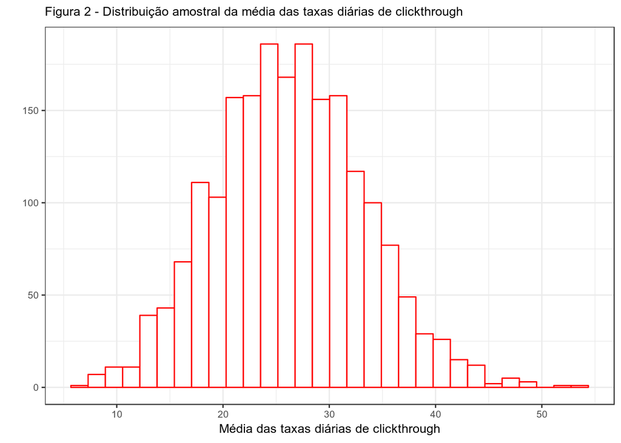

```r
tibble(estatistica = as.double(bootstraps$t)) %>%
  ggplot(aes(x = estatistica)) +
  geom_histogram(fill = "white", color = "red") +
  ggtitle("Figura 2 - Distribuição amostral da média das taxas diárias de clickthrough") +
  ylab(" ") +
  xlab("Média das taxas diárias de clickthrough") +
  theme(text = element_text(family = "Arial", size = 10), plot.title = element_text(size = 10), axis.title.x = element_text(size = 10), axis.title.y = element_text(size = 10))
```

```r
boot.ci(bootstraps, conf = 0.95, type = "perc")   ## calculando o intervalo de confiança
```

```
## BOOTSTRAP CONFIDENCE INTERVAL CALCULATIONS
## Based on 2000 bootstrap replicates
##
## CALL :
## boot.ci(boot.out = bootstraps, conf = 0.95, type = "perc")
##
## Intervals :
## Level     Percentile
## 95%   (13.06, 40.62 )
## Calculations and Intervals on Original Scale
```

Portanto, para a amostra, pode-se afirmar com 95% de confiança que a média de taxas diárias de *clickthrough* geral está entre 13,06% e 40,62%.

##### **Como isso varia entre os grupos?**

##### *Teste A/B*

Nesta parte, considera-se a variação da taxa diária de *clickthrough* em termos da comparação entre os usuários do grupo A e B. Para fins de inferência estatística, utiliza-se a **média das taxas diárias de *clickthrough*** .

O processo de *bootstraping* é realizado a partir da amostra (armazenada em *experimento*). A figura 3 mostra a distribuição da diferença entre as médias das taxas diárias de clickthrough para os grupos A e B. Em seguida, o intervalo de confiança para a diferença é calculado.

```r
bootstrap_group_function <- function(data, index){

  mean_rate_of_sessions_with_clicks_by_group = data %>%
      slice(index) %>%
      group_by(group, date(session_start_date)) %>%
      summarize(total_sessions_by_date = n(),
            total_sessions_with_clicks_by_date = sum(num_clicks > 0),
            rate = (total_sessions_with_clicks_by_date/total_sessions_by_date) * 100) %>%
      summarize(mean_rate = mean(rate)) %>%
      pull(mean_rate)

    return(mean_rate_of_sessions_with_clicks_by_group[1] - mean_rate_of_sessions_with_clicks_by_group[2])

}

bootstraps <- boot(experimento, bootstrap_group_function, R = 2000)
glimpse(bootstraps$t)
```

```
##  num [1:2000, 1] 7.99 -2.14 -45.49 -10.24 1.25 ...
```

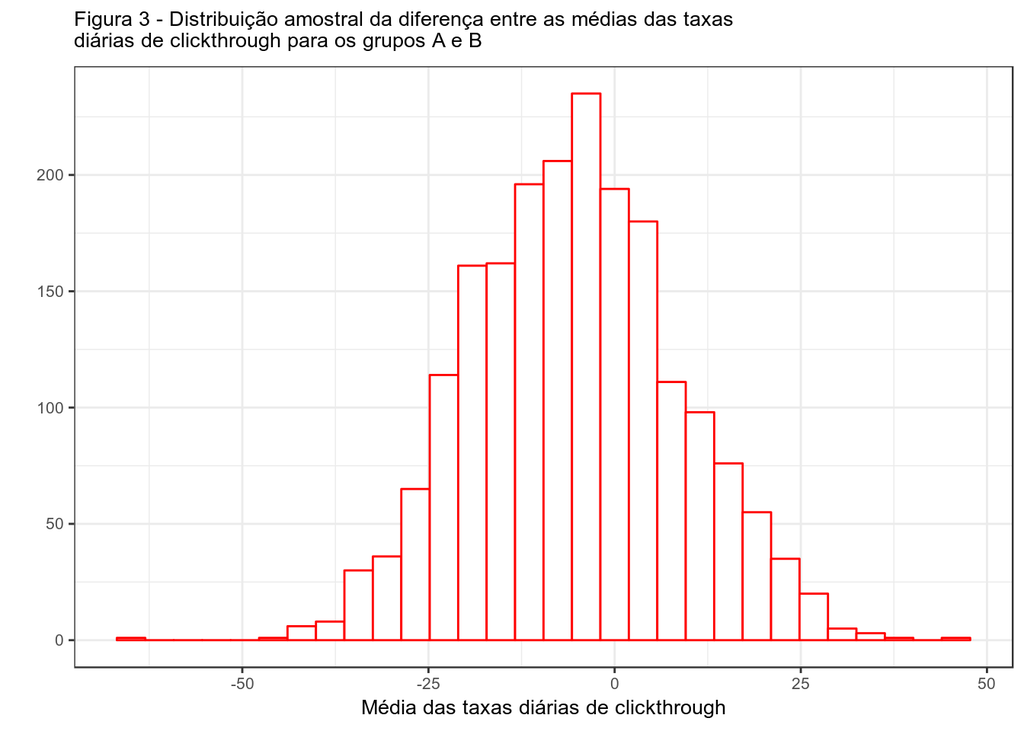

```r
tibble(estatistica = as.double(bootstraps$t)) %>%
  ggplot(aes(x = estatistica)) +
  geom_histogram(fill = "white", color = "red") +
  ggtitle("Figura 3 - Distribuição amostral da diferença entre as médias das taxas\ndiárias de clickthrough para os grupos A e B") +
  ylab(" ") +
  xlab("Média das taxas diárias de clickthrough") +
  theme(text = element_text(family = "Arial", size = 10), plot.title = element_text(size = 10), axis.title.x = element_text(size = 10), axis.title.y = element_text(size = 10))
```

```r
boot.ci(bootstraps, conf = 0.95, type = "perc")
```

```
## BOOTSTRAP CONFIDENCE INTERVAL CALCULATIONS
## Based on 2000 bootstrap replicates
##
## CALL :
## boot.ci(boot.out = bootstraps, conf = 0.95, type = "perc")
##
## Intervals :
## Level     Percentile
## 95%   (-31.903,  22.851 )
## Calculations and Intervals on Original Scale
```

Com 95% de confiança, afirma-se que o intervalo de confiança (-31,903 a 22,851) contêm as verdadeiras diferenças entre os grupos. E, uma vez que este intervalo inclui o valor zero, as diferenças não são estatisticamente significativas quanto às médias das taxas diárias de *clickthrough* entre os grupos A e B, isto é, não há evidências de diferenças entre os grupos.

##### *Teste A/A*

Novamente, é considerada a amostra de tamanho 40 (armazenada em *experimento*). Após o *bootstraping*, é exibida a distribuição amostral da diferença entre as médias das taxas diárias de clickthrough para as metades do grupo A (figura 4) e o intervalo de confiança para a diferença é calculado.

```r
bootstrap_groupA_function <- function(data, index){   ## computa a estatística de interesse e é um parâmetro para boot
    data <- data %>%
      slice(index)

    half <- data %>%
      head(nrow(data)/2) %>%
      mutate(group_half = "Primeira metade")

    other_half <- data %>%
      tail(nrow(data)/2) %>%
      mutate(group_half = "Segunda metade")

    sample_group_a = bind_rows(half, other_half)

    mean_rate_of_sessions_with_clicks_group_a = sample_group_a %>%
      group_by(group_half, date(session_start_date)) %>%
      summarize(total_sessions_by_date = n(),
            total_sessions_with_clicks_by_date = sum(num_clicks > 0),
            rate = (total_sessions_with_clicks_by_date/total_sessions_by_date) * 100) %>%
      summarize(mean_rate = mean(rate)) %>% ## média das taxas diárias de clickthrough
      pull(mean_rate)  ##variável de interesse

    return(mean_rate_of_sessions_with_clicks_group_a[1] - mean_rate_of_sessions_with_clicks_group_a[2])
}

bootstraps <- boot(experimento, bootstrap_groupA_function, R = 2000)
glimpse(bootstraps$t)
```

```
##  num [1:2000, 1] 2.976 -0.298 17.857 -13.095 -7.54 ...
```

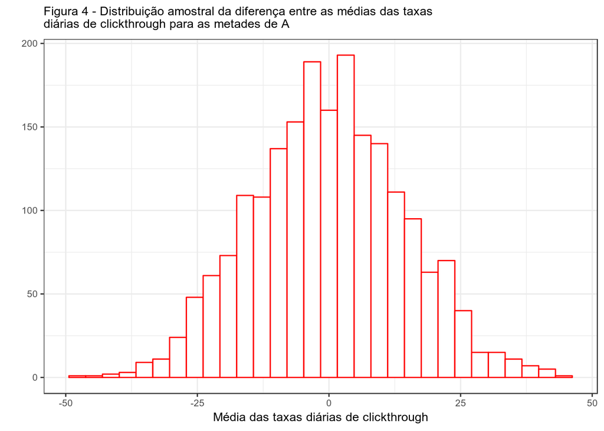

```r
tibble(estatistica = as.double(bootstraps$t)) %>%
  ggplot(aes(x = estatistica)) +
  geom_histogram(fill = "white", color = "red") +
  ggtitle("Figura 4 - Distribuição amostral da diferença entre as médias das taxas\ndiárias de clickthrough para as metades de A") +
  ylab(" ") +
  xlab("Média das taxas diárias de clickthrough") +
  theme(text = element_text(family = "Arial", size = 10), plot.title = element_text(size = 10), axis.title.x = element_text(size = 10), axis.title.y = element_text(size = 10))
```

```r
boot.ci(bootstraps, conf = 0.95, type = "perc")
```

```
## BOOTSTRAP CONFIDENCE INTERVAL CALCULATIONS
## Based on 2000 bootstrap replicates
##
## CALL :
## boot.ci(boot.out = bootstraps, conf = 0.95, type = "perc")
##
## Intervals :
## Level     Percentile
## 95%   (-27.377,  27.967 )
## Calculations and Intervals on Original Scale
```

O intervalo de confiança (-27,377 a 27,967) contêm as verdadeiras diferenças entre os subgrupos de A, com 95% de confiança. Dado que o intervalo de confiança inclui o valor zero, não há evidências de diferença estatisticamente significativa entre os subgrupos.

#### **3.2 Quais resultados de busca, as pessoas tendem a tentar primeiro? Como isso muda no dia-a-dia?**

##### **Quais resultados de busca, as pessoas tendem a tentar primeiro?**

A variável *first_click* armazena a posição do primeiro resultado de busca clicado, por sessão. Sendo assim, são utilizados apenas os valores diferentes de *NA* para essa variável e valores maiores que 0 para a variável *results*, pois estas enfatizam que a busca gerou resultados e que o usuário clicou em algum link. Uma vez que o *dataframe* buscas já fitrou *resultados* menores ou iguais a zero, será efetuada a filtragem de buscas com relação à variável *first_click*, a seguir.

```r
buscas = buscas %>% ## excluindo possíveis valores inesperados para a variável
  filter(!is.na(first_click)) %>%
  filter(first_click != 0)
glimpse(buscas) ##visualizando as observações pós-filtragem
```

```
## Observations: 33,187
## Variables: 8
## $ session_id              <chr> "0001382e027b2ea4", "0001e8bb90445cb2"...
## $ search_index            <int> 1, 1, 2, 1, 1, 1, 2, 2, 1, 3, 2, 1, 1,...
## $ session_start_timestamp <dbl> 2.016031e+13, 2.016031e+13, 2.016031e+...
## $ session_start_date      <dttm> 2016-03-07 08:49:55, 2016-03-05 09:24...
## $ group                   <chr> "b", "b", "a", "a", "b", "a", "a", "a"...
## $ results                 <int> 18, 20, 1, 20, 20, 20, 20, 20, 9, 20, ...
## $ num_clicks              <int> 1, 1, 1, 3, 1, 1, 1, 1, 1, 1, 1, 1, 1,...
## $ first_click             <int> 1, 1, 1, 1, 5, 1, 1, 1, 1, 4, 1, 1, 2,...
```

Pós-filtragem, há 33.187 observações disponíveis. A figura 5 exibe a distribuição da posição do primeiro clique efetuado pelo usuário, por sessão de busca.

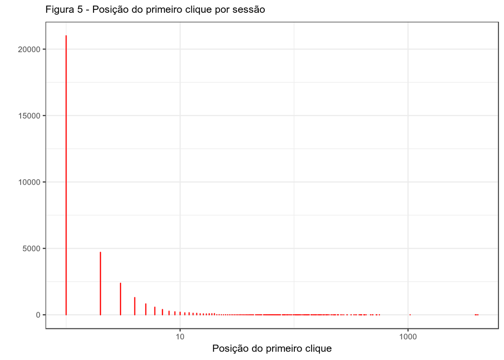

```r
buscas %>%
    ggplot(aes(x = first_click)) +
    ggtitle("Figura 5 - Posição do primeiro clique por sessão") +
    geom_bar(bins = 10, fill = "white", color = "red") +
    scale_x_log10() +
    ylab(" ") +
    xlab("Posição do primeiro clique") +
    theme(text = element_text(family = "Arial", size = 10), plot.title = element_text(size = 10), axis.title.x = element_text(size = 10), axis.title.y = element_text(size = 10))
```

É possível perceber, que a maioria dos usuários tendem a clicar nos resultados de busca que estão nas posições de 1 a 10, embora sejam percebidos *outliers*. Na presença desses valores extremos, é relevante observar a média e mediana das posições.

```r
print(mean(buscas$first_click))
```

```
## [1] 3.924308
```

```r
print(median(buscas$first_click))
```

```
## [1] 1
```

Assim, o processo de *bootstraping* é iniciado, considerando uma amostra extraída do *dataframe* buscas. A figura 6 exibe a distribuição amostral das medianas da posição do primeiro clique, geradas. Em sequência, o intervalo de confiança é calculado.

```r
experimento = sample_n(buscas, 40)     ## coleta-se nova amostra para responder a pergunta 3.2, pois o dataframe sofreu filtragem
glimpse(experimento)                    ## exibe a amostra extraída do dataframe
```

```
## Observations: 40
## Variables: 8
## $ session_id              <chr> "4ad87eaeb256518d", "12ea8250d3068b2c"...
## $ search_index            <int> 1, 1, 1, 1, 3, 1, 1, 1, 46, 2, 9, 1, 2...
## $ session_start_timestamp <dbl> 2.016031e+13, 2.016031e+13, 2.016030e+...
## $ session_start_date      <dttm> 2016-03-06 04:49:59, 2016-03-08 15:21...
## $ group                   <chr> "a", "a", "a", "a", "a", "a", "a", "a"...
## $ results                 <int> 1, 20, 20, 20, 20, 20, 20, 20, 20, 20,...
## $ num_clicks              <int> 1, 1, 3, 3, 1, 3, 1, 1, 1, 1, 1, 1, 10...
## $ first_click             <int> 1, 1, 1, 1, 38, 1, 5, 1, 203, 1, 6, 1,...
```

```r
bootstrap_median_function <- function(data, index){   ## computa a estatística de interesse e é um parâmetro para boot
    median_first_click = data %>%
      slice(index) %>%       ##reamostragem
      pull(first_click) %>%  ##variável de interesse
      median()               ## mediana das posição do primeiro clique para a esta reamostragem

    return(median_first_click)
}

bootstraps <- boot(experimento, bootstrap_median_function, R = 2000)  ## número de repetições é 2000

glimpse(bootstraps$t)
```

```
##  num [1:2000, 1] 1 1 1 1 1 1 1 1 1 1 ...
```

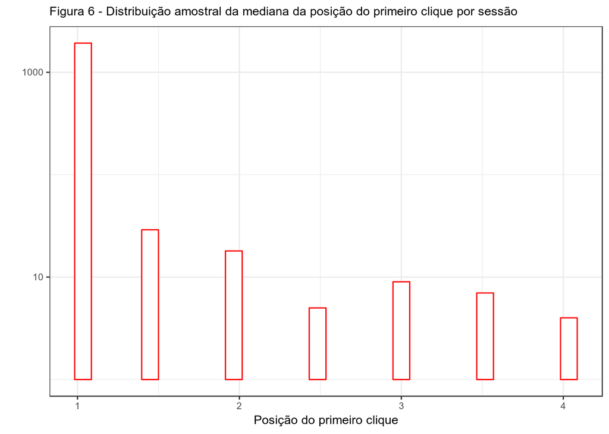

```r
tibble(estatistica = as.double(bootstraps$t)) %>%
  ggplot(aes(x = estatistica)) +
  geom_histogram(fill = "white", color = "red") +
  ggtitle("Figura 6 - Distribuição amostral da mediana da posição do primeiro clique por sessão") +
  ylab(" ") +
  xlab("Posição do primeiro clique") +
  scale_y_log10() +
  theme(text = element_text(family = "Arial", size = 10), plot.title = element_text(size = 10), axis.title.x = element_text(size = 10), axis.title.y = element_text(size = 10))
```

```r
boot.ci(bootstraps, conf = 0.95, type = "basic")   ## calculando o intervalo de confiança
```

```
## BOOTSTRAP CONFIDENCE INTERVAL CALCULATIONS
## Based on 2000 bootstrap replicates
##
## CALL :
## boot.ci(boot.out = bootstraps, conf = 0.95, type = "basic")
##
## Intervals :
## Level      Basic
## 95%   ( 0.5,  1.0 )
## Calculations and Intervals on Original Scale
```

##### **Como isso muda no dia-a-dia?**

Nesta análise, considera-se a data de realização de uma sessão (*session_start_date*). A figura 7 exibe a distribuição da posição do primeiro clique por data de ocorrência da busca.

```r
first_click_in_sessions_by_date = buscas %>%
    group_by(date(session_start_date)) %>%
    summarize(mediana = median(first_click))

glimpse(first_click_in_sessions_by_date)
```

```
## Observations: 8
## Variables: 2
## $ `date(session_start_date)` <date> 2016-03-01, 2016-03-02, 2016-03-03...
## $ mediana                    <dbl> 1, 1, 1, 1, 1, 1, 1, 1
```

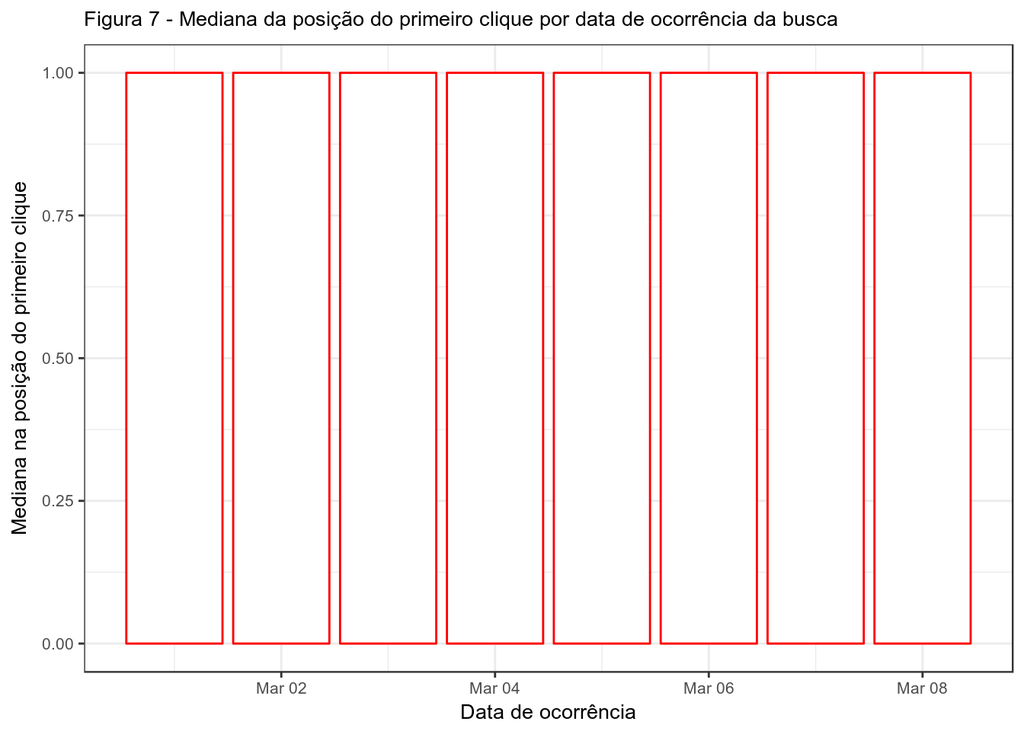

```r
first_click_in_sessions_by_date %>%
    ggplot(aes(y = mediana, x = `date(session_start_date)`)) +
    ggtitle("Figura 7 - Mediana da posição do primeiro clique por data de ocorrência da busca") +
    geom_bar(stat = "identity", fill = "white", color = "red") +
    ylab("Mediana na posição do primeiro clique") +
    xlab("Data de ocorrência") +
    theme(text = element_text(family = "Arial", size = 10), plot.title = element_text(size = 10), axis.title.x = element_text(size = 10), axis.title.y = element_text(size = 10))
```

Portanto, nota-se que ao longo dos dias observados, confirma-se que o valor mediano da posição do primeiro clique é igual a 1.

```
## [1] "Data:  2016-03-01"
```

```
## [1] "Calculando o intervalo de confiança para : 2016-03-01"
## [1] "All values of t are equal to  1 \n Cannot calculate confidence intervals"
## NULL
## [1] "Data:  2016-03-02"
```

```
## [1] "Calculando o intervalo de confiança para : 2016-03-02"
## [1] "All values of t are equal to  1 \n Cannot calculate confidence intervals"
## NULL
## [1] "Data:  2016-03-03"
```

```
## [1] "Calculando o intervalo de confiança para : 2016-03-03"
## [1] "All values of t are equal to  1 \n Cannot calculate confidence intervals"
## NULL
## [1] "Data:  2016-03-04"
```

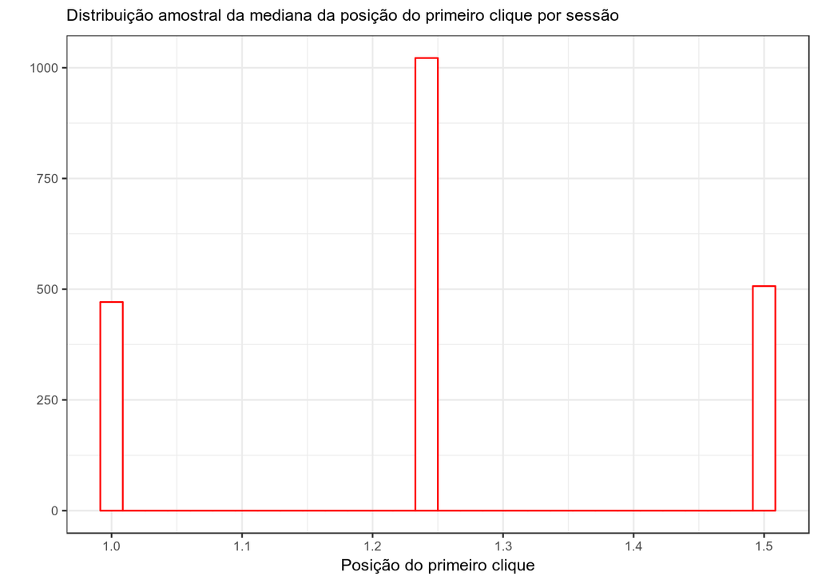

```
## [1] "Calculando o intervalo de confiança para : 2016-03-04"
## BOOTSTRAP CONFIDENCE INTERVAL CALCULATIONS
## Based on 2000 bootstrap replicates
##
## CALL :
## boot.ci(boot.out = bootstraps, conf = 0.95, type = "basic")
##
## Intervals :
## Level      Basic
## 95%   ( 1.0,  1.5 )
## Calculations and Intervals on Original Scale
## [1] "Data:  2016-03-05"
```

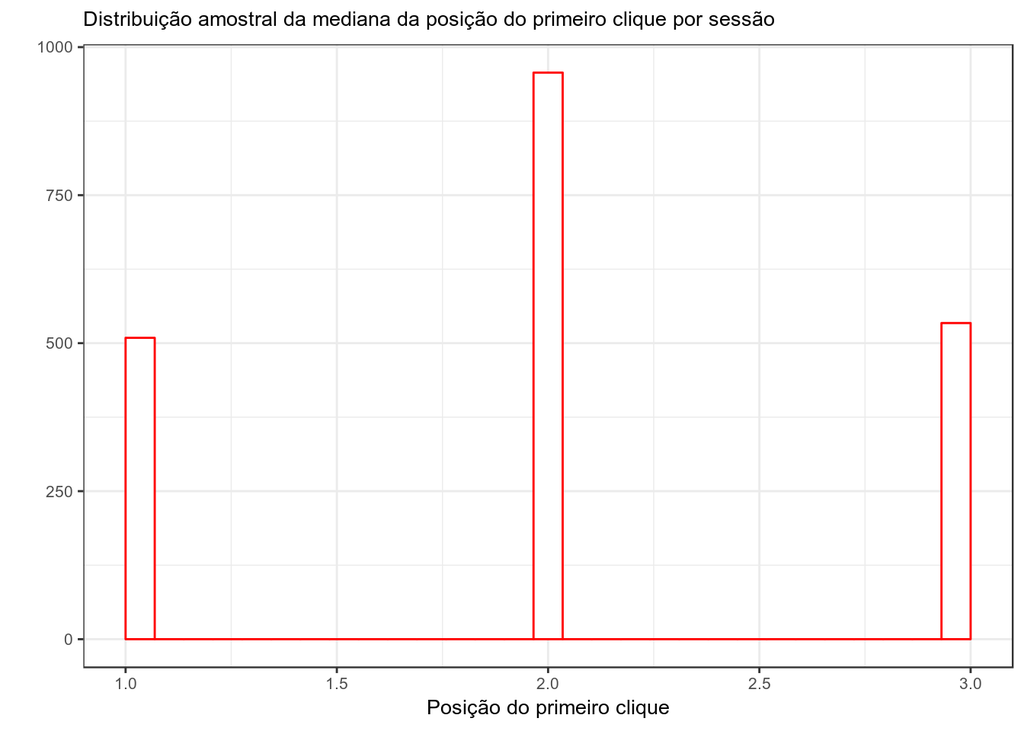

```
## [1] "Calculando o intervalo de confiança para : 2016-03-05"
## BOOTSTRAP CONFIDENCE INTERVAL CALCULATIONS
## Based on 2000 bootstrap replicates
##
## CALL :
## boot.ci(boot.out = bootstraps, conf = 0.95, type = "basic")
##
## Intervals :
## Level      Basic
## 95%   ( 1,  3 )
## Calculations and Intervals on Original Scale
## [1] "Data:  2016-03-06"
```

```
## [1] "Calculando o intervalo de confiança para : 2016-03-06"
## [1] "All values of t are equal to  1 \n Cannot calculate confidence intervals"
## NULL
## [1] "Data:  2016-03-07"
```

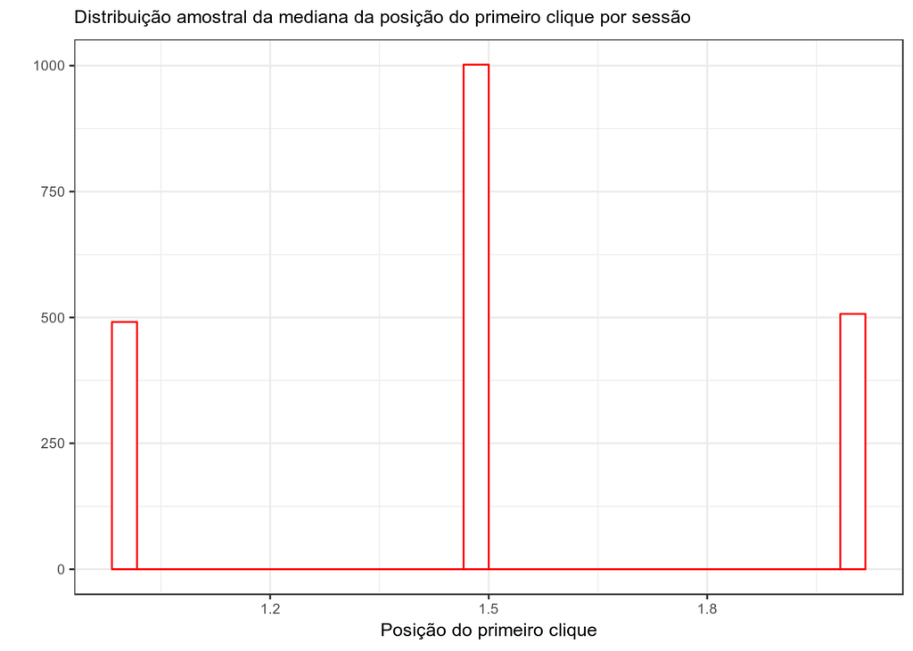

```
## [1] "Calculando o intervalo de confiança para : 2016-03-07"
## BOOTSTRAP CONFIDENCE INTERVAL CALCULATIONS
## Based on 2000 bootstrap replicates
##
## CALL :
## boot.ci(boot.out = bootstraps, conf = 0.95, type = "basic")
##
## Intervals :
## Level      Basic
## 95%   ( 1,  2 )
## Calculations and Intervals on Original Scale
## [1] "Data:  2016-03-08"
```

```
## [1] "Calculando o intervalo de confiança para : 2016-03-08"
## [1] "All values of t are equal to  1 \n Cannot calculate confidence intervals"
## NULL
```

```r
first_click_in_sessions_by_date_function <- function(data, date){
  first_click_day = data %>%
      group_by(date(session_start_date) == date) %>%
      summarize(median_first_click = median(first_click))
  return(first_click_day)
}

bootstrap_median_date_function <- function(data, index){   ## computa a estatística de interesse e é um parâmetro para boot
  median_first_click_by_date = data %>%
      slice(index) %>%       ##reamostragem
      pull(median_first_click) %>%  ##variável de interesse
      median()               ## mediana das posição do primeiro clique para a esta reamostragem

    return(median_first_click_by_date)
}

show_bootstrap_function <- function(data){
      print(tibble(estatistica = as.double(data$t)) %>%
      ggplot(aes(x = estatistica)) +
      geom_histogram(fill = "white", color = "red") +
      ggtitle("Distribuição amostral da mediana da posição do primeiro clique por sessão") +
      ylab(" ") +
      xlab("Posição do primeiro clique") +
      theme(text = element_text(family = "Arial", size = 10), plot.title = element_text(size = 10), axis.title.x = element_text(size = 10), axis.title.y = element_text(size = 10)))
  }

bootstrap_total_function <- function(data){
  dates <- seq(as.Date("2016-03-01"), by = 1, len = 8) ##ver depois como deixar automático

  for(d in 1:length(dates)){
      bootstraps <- boot(first_click_in_sessions_by_date_function(experimento, as.Date(dates[d])), bootstrap_median_date_function, R = 2000)
      print(paste('Data: ', as.Date(dates[d])))
      show_bootstrap_function(bootstraps)
      print(paste("Calculando o intervalo de confiança para :", as.Date(dates[d])))
      print(boot.ci(bootstraps, conf = 0.95, type = "basic"))
  }
}

bootstrap_total_function(experimento)
```

#### **3.3 Qual é taxa diária de zero resultados? Como isso varia entre os grupos?**

##### **Qual é taxa diária de zero resultados?**

Para esta pergunta, consideram-se apenas os valores iguais a *0* para a variável **results** e o *dataset* original.

```r
buscas_original <- buscas_original %>%
  filter(!is.na(results))

glimpse(buscas_original) ##visualizando as observações pós-filtragem
```

```
## Observations: 136,234
## Variables: 8
## $ session_id              <chr> "0000cbcb67c19c45", "0001382e027b2ea4"...
## $ search_index            <int> 1, 1, 1, 1, 2, 3, 4, 5, 6, 1, 1, 2, 1,...
## $ session_start_timestamp <dbl> 2.016030e+13, 2.016031e+13, 2.016031e+...
## $ session_start_date      <dttm> 2016-03-03 15:20:45, 2016-03-07 08:49...
## $ group                   <chr> "b", "b", "b", "a", "a", "a", "a", "a"...
## $ results                 <int> 20, 18, 20, 20, 20, 20, 20, 20, 20, 1,...
## $ num_clicks              <int> 0, 1, 1, 0, 0, 0, 0, 0, 0, 0, 0, 1, 0,...
## $ first_click             <int> NA, 1, 1, NA, NA, NA, NA, NA, NA, NA, ...
```

A partir da tabela, nota-se que há 136.234 observações a considerar. As taxas diárias de zero resultados são armazenadas no *dataframe* sessions_by_date.

```r
sessions_by_date = buscas_original %>%
  group_by(date(session_start_date)) %>%       ##agrupando por data da ocorrência da sessão
  summarize(total_sessions_by_date = n(),
            total_sessions_with_zero_results_by_date = sum(results == 0),
            rate = (total_sessions_with_zero_results_by_date/total_sessions_by_date) * 100)

glimpse(sessions_by_date)
```

```
## Observations: 8
## Variables: 4
## $ `date(session_start_date)`               <date> 2016-03-01, 2016-03-...
## $ total_sessions_by_date                   <int> 18374, 18902, 19159, ...
## $ total_sessions_with_zero_results_by_date <int> 3447, 3589, 3443, 301...
## $ rate                                     <dbl> 18.76020, 18.98741, 1...
```

A figura 8 exibe a distribuição de taxas de zero resultados por data de ocorrência.

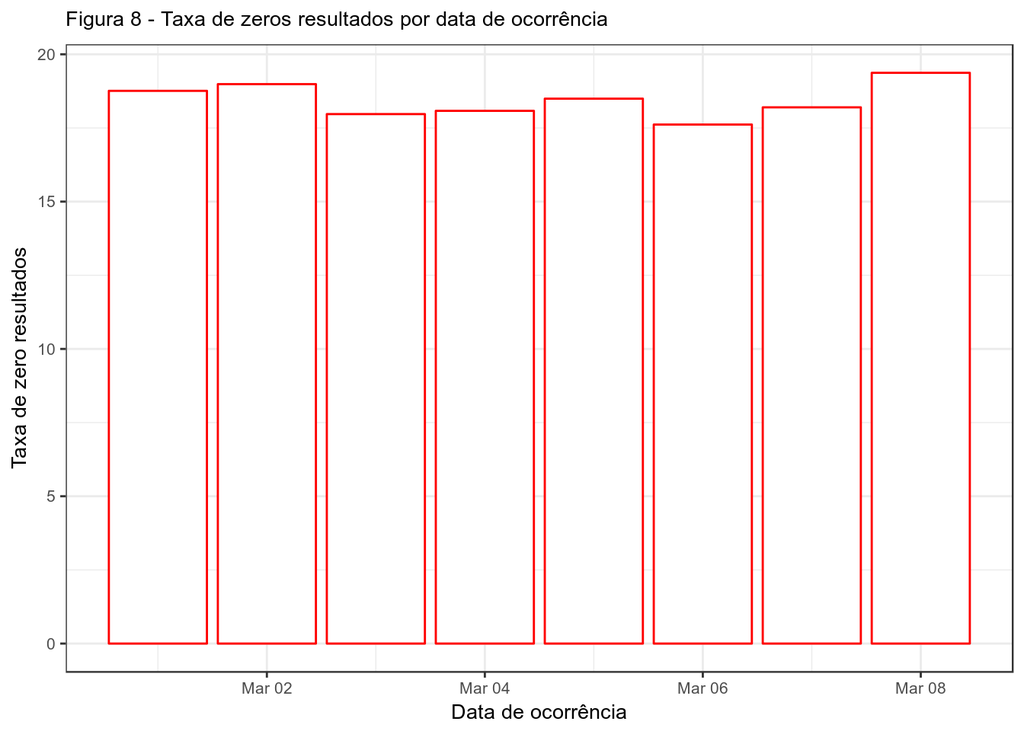

```r
sessions_by_date %>%
    ggplot(aes(y = rate, x = `date(session_start_date)`)) +
    ggtitle("Figura 8 - Taxa de zeros resultados por data de ocorrência") +
    geom_bar(stat = "identity", fill = "white", color = "red") +
    ylab("Taxa de zero resultados") +
    xlab("Data de ocorrência") +
    theme(text = element_text(family = "Arial", size = 10), plot.title = element_text(size = 10), axis.title.x = element_text(size = 10), axis.title.y = element_text(size = 10))
```

Calcula-se a média das taxas diárias de zero resultados.

```r
print(mean(sessions_by_date$rate))
```

```
## [1] 18.43512
```

Portanto, em 18,43% das sessões diárias, os usuários obtém zero resultados, em média. Nesse contexto, a média das taxas diárias de zero resultados será considerada para fins de inferência estatística.

A partir do *dataframe* **buscas_original**, é extraída uma amostra de tamanho 40 e o processo de *bootstraping* é iniciado. A figura 9 exibe a distribuição amostral das médias de taxas diárias de zero resultados, geradas via *bootstrap*. Em seguida, o intervalo de confiança é calculado.

```r
experimento = sample_n(buscas_original, 40)   ## obtém amostra de tamanho 40
glimpse(experimento)                    ## exibe a amostra extraída do dataframe
```

```
## Observations: 40
## Variables: 8
## $ session_id              <chr> "6a5b4340dc18515d", "b40e505d8b0e5daa"...
## $ search_index            <int> 1, 3, 2, 7, 66, 1, 1, 1, 1, 1, 2, 1, 1...
## $ session_start_timestamp <dbl> 2.016030e+13, 2.016031e+13, 2.016030e+...
## $ session_start_date      <dttm> 2016-03-01 08:00:54, 2016-03-06 18:07...
## $ group                   <chr> "b", "a", "a", "a", "a", "b", "a", "a"...
## $ results                 <int> 0, 7, 20, 20, 19, 20, 20, 1, 4, 20, 20...
## $ num_clicks              <int> 0, 1, 0, 0, 0, 0, 1, 0, 1, 1, 0, 1, 0,...
## $ first_click             <int> NA, 1, NA, NA, NA, NA, 1, NA, 1, 1, NA...
```

```r
bootstrap_function <- function(data, index){   ## computa a estatística de interesse e é um parâmetro para boot
    mean_rate_of_sessions_with_zero_results_by_date = data %>%
      slice(index) %>%       ##reamostragem
      group_by(date(session_start_date)) %>%       ##agrupando por data da ocorrência da sessão
      summarize(total_sessions_by_date = n(),
            total_sessions_with_zero_results_by_date = sum(results == 0),
            rate = (total_sessions_with_zero_results_by_date/total_sessions_by_date) * 100) %>%
      pull(rate) %>%  ##variável de interesse
      mean()        ## média das taxas diárias de zero resultados

    return(mean_rate_of_sessions_with_zero_results_by_date)
}

bootstraps <- boot(experimento, bootstrap_function, R = 2000)  ## número de repetições é 2000

glimpse(bootstraps$t)
```

```
##  num [1:2000, 1] 15.7 11 10.4 17.4 18.9 ...
```

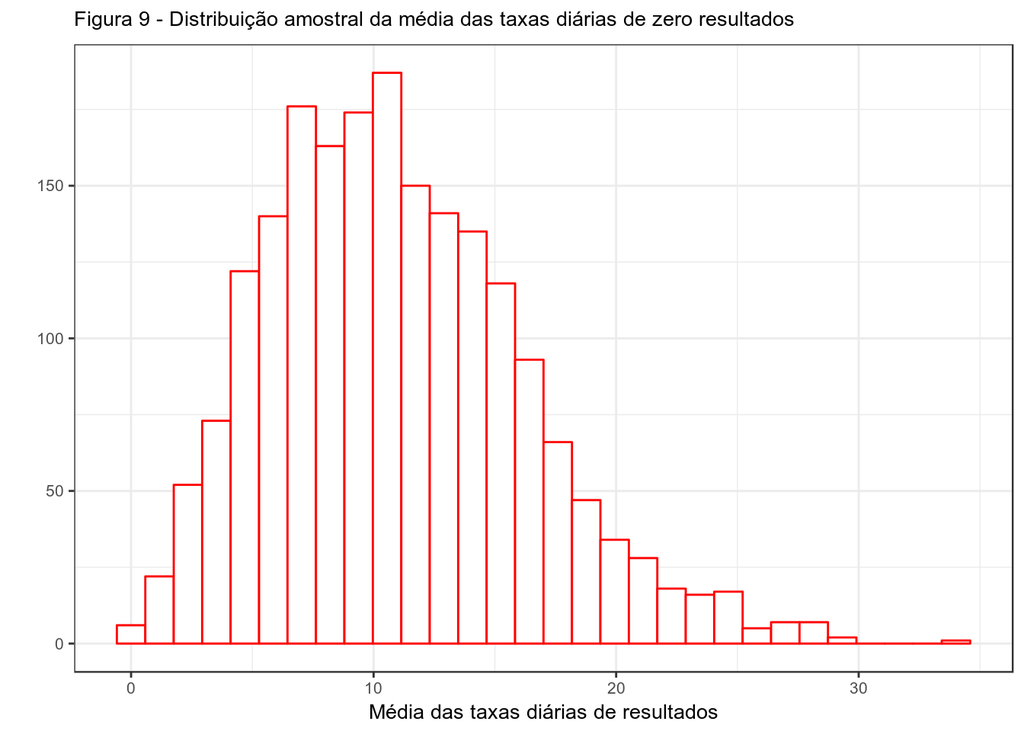

```r
tibble(estatistica = as.double(bootstraps$t)) %>%
  ggplot(aes(x = estatistica)) +
  geom_histogram(fill = "white", color = "red") +
  ggtitle("Figura 9 - Distribuição amostral da média das taxas diárias de zero resultados") +
  ylab(" ") +
  xlab("Média das taxas diárias de resultados") +
  theme(text = element_text(family = "Arial", size = 10), plot.title = element_text(size = 10), axis.title.x = element_text(size = 10), axis.title.y = element_text(size = 10))
```

```r
boot.ci(bootstraps, conf = 0.95, type = "perc")   ## calculando o intervalo de confiança
```

```
## BOOTSTRAP CONFIDENCE INTERVAL CALCULATIONS
## Based on 2000 bootstrap replicates
##
## CALL :
## boot.ci(boot.out = bootstraps, conf = 0.95, type = "perc")
##
## Intervals :
## Level     Percentile
## 95%   ( 2.38, 23.06 )
## Calculations and Intervals on Original Scale
```

Portanto, pode-se afirmar com 95% de confiança que a média de taxas diárias de zero resultados está entre 2,38% e 23,06%.

##### **Como isso varia entre os grupos?**

Para esta pergunta, considera-se a variação da taxa diária de zero resultados dos grupos A e B, ou seja, um teste A/B. Para fins de inferência estatística, utiliza-se a **média das taxas diárias de zero resultados**.

O processo de *bootstraping* é realizado a partir da amostra (armazenada em *experimento*). A figura 10 mostra a distribuição da diferença entre as médias das taxas diárias de zero resultados para os grupos A e B. Em seguida, o intervalo de confiança para a diferença é calculado.

```r
bootstrap_group_function <- function(data, index){   ## computa a estatística de interesse e é um parâmetro para boot

  mean_rate_of_sessions_with_zero_results_by_group = data %>%
      slice(index) %>%
      group_by(group, date(session_start_date)) %>%
      summarize(total_sessions_by_date = n(),
            total_sessions_with_zero_results_by_date = sum(results == 0),
            rate = (total_sessions_with_zero_results_by_date/total_sessions_by_date) * 100) %>%
      summarize(mean_rate = mean(rate)) %>% ## média das taxas diárias de zero resultados
      pull(mean_rate)  ##variável de interesse

    return(mean_rate_of_sessions_with_zero_results_by_group[1] - mean_rate_of_sessions_with_zero_results_by_group[2])

}

bootstraps <- boot(experimento, bootstrap_group_function, R = 2000)
glimpse(bootstraps$t)
```

```
##  num [1:2000, 1] -13.333 -0.442 -38.194 0.167 -7.738 ...
```

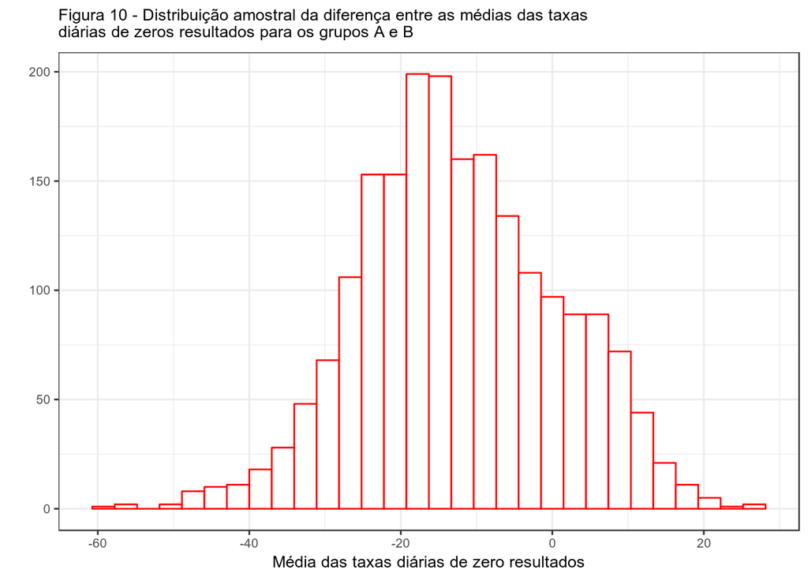

```r
tibble(estatistica = as.double(bootstraps$t)) %>%
  ggplot(aes(x = estatistica)) +
  geom_histogram(fill = "white", color = "red") +
  ggtitle("Figura 10 - Distribuição amostral da diferença entre as médias das taxas\ndiárias de zeros resultados para os grupos A e B") +
  ylab(" ") +
  xlab("Média das taxas diárias de zero resultados") +
  theme(text = element_text(family = "Arial", size = 10), plot.title = element_text(size = 10), axis.title.x = element_text(size = 10), axis.title.y = element_text(size = 10))
```

```r
boot.ci(bootstraps, conf = 0.95, type = "perc")
```

```
## BOOTSTRAP CONFIDENCE INTERVAL CALCULATIONS
## Based on 2000 bootstrap replicates
##
## CALL :
## boot.ci(boot.out = bootstraps, conf = 0.95, type = "perc")
##
## Intervals :
## Level     Percentile
## 95%   (-37.64,  12.85 )
## Calculations and Intervals on Original Scale
```

O intervalo de confiança inclui zero, constatando que as diferenças entre os grupos A e B não são estatisticamente significativas. Com 95% de confiança, afirma-se que o intervalo (-37,64 a 12,85) contêm as verdadeiras diferenças entre os grupos.

### **4. Conclusões**

Sabe-se que o intervalo de confiança representa a amplitude de valores que têm probabilidade (definida de acordo com o nível de confiança) de conter o verdadeiro valor da população. Sendo assim, com **95% de confiança**, as seguintes conclusões a respeito da população, podem ser inferidas:

- A taxa diária de *clickthrough* é um dos valores no intervalo (13,06% a 40,62%). No teste A/B, obteve-se um intervalo de confiança (-31,903 a 22,851) que inclui o valor zero e, portanto, conclui-se que não há diferenças significativas entre a taxa diária de *clickthrough* para os grupos A e B. No teste A/A, o intervalo de confiança (-27,377 a 27,967) inclui zero, assim, também não há evidências de diferenças estatisticamente significativas para a taxa, entre os subgrupos de A;
- No geral, em 50% das sessões, os resultados na posição 1 são clicados primeiro pelos usuários. Infere-se que, ao longo dos dias, em 50% das sessões, os resultados nas posições de 1 a 3 são clicados primeiro;
- A taxa diária de zero resultados está no intervalo de 2,38% a 23,06%. No teste A/B, confirma-se a partir do intervalo de confiança (-37,64% a 12,85%) que não há diferenças estatisticamente significativas entre os grupos A e B em termos dessa taxa, pois o intervalo inclui o valor zero.

Por fim, destaca-se que nos testes realizados (A/B e A/A), mesmo considerando taxas e variáveis distintas, não há diferenças estatísticas significativas, o que sugere um “comportamento padrão” dos usuários em termos da realização de buscas, independente do grupo ao qual pertence.